# HW 12- Mixed Model

Keanu Rochette

2025-04-17

## Load Libraries

```r
# Data manipulation and visualization
library(tidyverse)
library(here)
library(janitor)
library(grid)
library(patchwork)

# Data analysis/statistics
#library(glmmTMB)
library(car) #ANOVA
library(ggResidpanel) #residual panel
library(ggeffects)
library(effects) #dependency for ggeffects
library(MuMIn)
library(lme4)
library(lmerTest)
library(sjPlot)
```

## Load data

```r
archipel <- read_csv(here("HW12", "data", "cabral_arch_data.csv"))
island <- read_csv(here("HW12", "data", "cabral_island_data.csv"))


archipel <- clean_names(archipel)
island <- clean_names(island)
```

## Question 1:

*Make a model with species richness as the response, and with a random effect for Archipelago.*  
*What proportion of the variation in species richness occurs at the archipelago scale, and what proportion occurs within archipelagoes? Which archipelagoes are particularly diverse, and which are depauperate?*

```r
model1 <- lmer(log(species+1) ~ (1|archipelago), data = island)
```

```r
summary(model1)
```

```
## Linear mixed model fit by REML. t-tests use Satterthwaite's method [
## lmerModLmerTest]
## Formula: log(species + 1) ~ (1 | archipelago)
##    Data: island
##
## REML criterion at convergence: 501.2
##
## Scaled residuals:
##     Min      1Q  Median      3Q     Max
## -5.1507 -0.5357  0.0796  0.5790  1.9455
##
## Random effects:
##  Groups      Name        Variance Std.Dev.
##  archipelago (Intercept) 0.6408   0.8005
##  Residual                0.8243   0.9079
## Number of obs: 174, groups:  archipelago, 23
##
## Fixed effects:
##             Estimate Std. Error      df t value Pr(>|t|)
## (Intercept)   4.7685     0.1865 18.9104   25.57 3.94e-16 ***
## ---
## Signif. codes:  0 '***' 0.001 '**' 0.01 '*' 0.05 '.' 0.1 ' ' 1
```

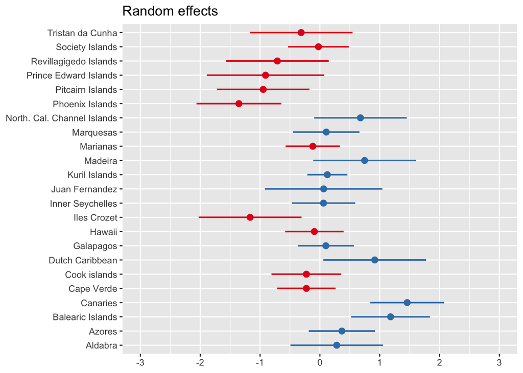

```r
plot_model(model1, type = "re")
```

With an arbitrary limit of 1 and -1:

- **Diverse archipelagos**: Canaries and Baleric Islands
- **Depauperate archipelagos**: Phoenix islands and Iles Crozet

## Question 2:

*Now let’s think about the six predictors. Make some exploratory plots of the effect of each variable on richness, plotted at the appropriate scale. You’ll need to merge the data sets. Think about which predictors might need to be transformed for use in a linear model.*

```r
biogeo <- left_join(archipel, island, by = "archipelago")
biogeo <- biogeo %>%  select(-x1.x, -x1.y)
summary(biogeo)
```

```
##  archipelago        number_islands     distance           age
##  Length:175         Min.   : 2.00   Min.   :  23.9   Min.   : 0.0075
##  Class :character   1st Qu.: 7.00   1st Qu.: 116.6   1st Qu.: 5.4750
##  Mode  :character   Median :11.00   Median :1205.5   Median :20.0000
##                     Mean   :11.72   Mean   :1867.1   Mean   :30.1010
##                     3rd Qu.:13.00   3rd Qu.:3162.2   3rd Qu.:57.0000
##                     Max.   :27.00   Max.   :5676.5   Max.   :90.0000
##                     NA's   :1       NA's   :1        NA's   :1
##     species            area                elev             temp
##  Min.   :   0.0   Min.   :    1.035   Min.   :   0.0   Min.   : 1.30
##  1st Qu.:  61.5   1st Qu.:   10.654   1st Qu.: 113.5   1st Qu.:17.00
##  Median : 136.5   Median :   59.468   Median : 411.0   Median :24.00
##  Mean   : 203.1   Mean   :  354.967   Mean   : 610.6   Mean   :19.94
##  3rd Qu.: 263.8   3rd Qu.:  273.176   3rd Qu.: 899.5   3rd Qu.:26.40
##  Max.   :1123.0   Max.   :10457.216   Max.   :4176.0   Max.   :28.50
##  NA's   :1        NA's   :1           NA's   :1        NA's   :1
```

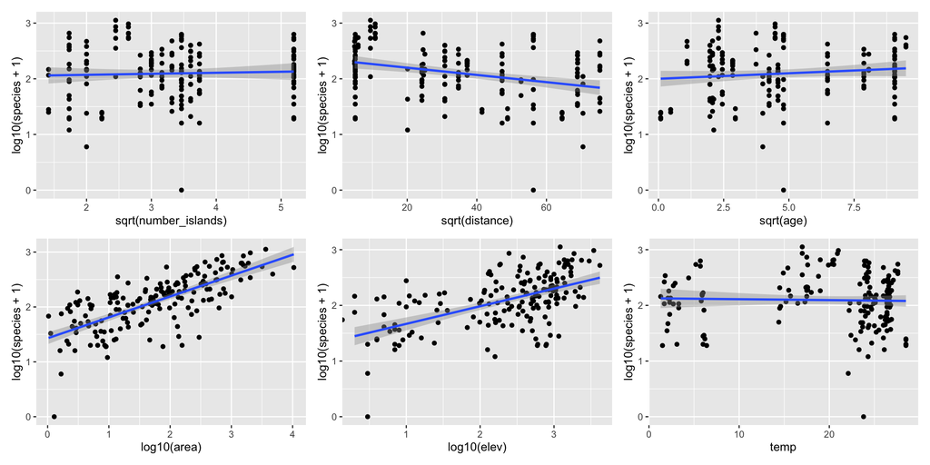

```r
(ggplot(biogeo, aes(sqrt(number_islands), log10(species+1)))+ geom_point() + geom_smooth(method = "lm")) +
  (ggplot(biogeo, aes(sqrt(distance), log10(species+1) ))+ geom_point()+geom_smooth(method = "lm") )+
  (ggplot(biogeo, aes(sqrt(age), log10(species+1)))+ geom_point()+geom_smooth(method = "lm"))+
  (ggplot(biogeo, aes(log10(area), log10(species+1))) + geom_point() + geom_smooth(method = "lm")) +
  (ggplot(biogeo, aes(log10(elev), log10(species+1)))+ geom_point()+geom_smooth(method = "lm"))+
  (ggplot(biogeo, aes(temp,log10(species+1)))+ geom_point()+geom_smooth(method = "lm"))
```

## Question 3

*Construct mixed model(s) that test the roles of the six predictors in explaining species richness.*

*Plot fitted (fixed) effects as well as random effect estimates, plus model diagnostics.*

*Calculate how much variation the predictors explain, at the two different scales in the data (island and archipelago)? i.e., present R^2 values for the two scales. Also, how much of the total variation have they explained, according to R^2[GLMM(m)]?*

### Number of Islands

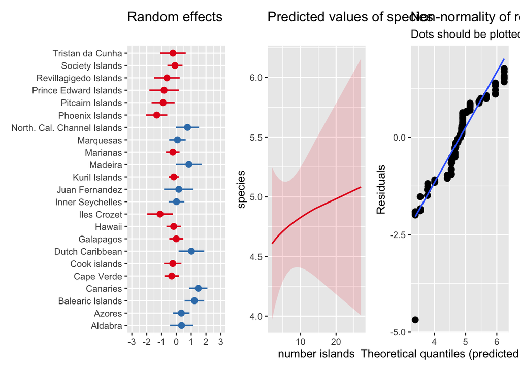

```r
n_isl <- lmer(log(species+1) ~ sqrt(number_islands) + (1|archipelago), data = biogeo)

(plot_model(n_isl, type = "re")) +
  (plot_model(n_isl, type = "eff", terms = c('number_islands'))) +
  (plot_model(n_isl, type = "diag")[[1]])
```

```r
anova(n_isl, type = '2')
```

```
## Type II Analysis of Variance Table with Satterthwaite's method
##                       Sum Sq Mean Sq NumDF  DenDF F value Pr(>F)
## sqrt(number_islands) 0.31195 0.31195     1 17.583  0.3791  0.546
```

```r
VarCorr(n_isl)
```

```
##  Groups      Name        Std.Dev.
##  archipelago (Intercept) 0.82125
##  Residual                0.90710
```

### Area

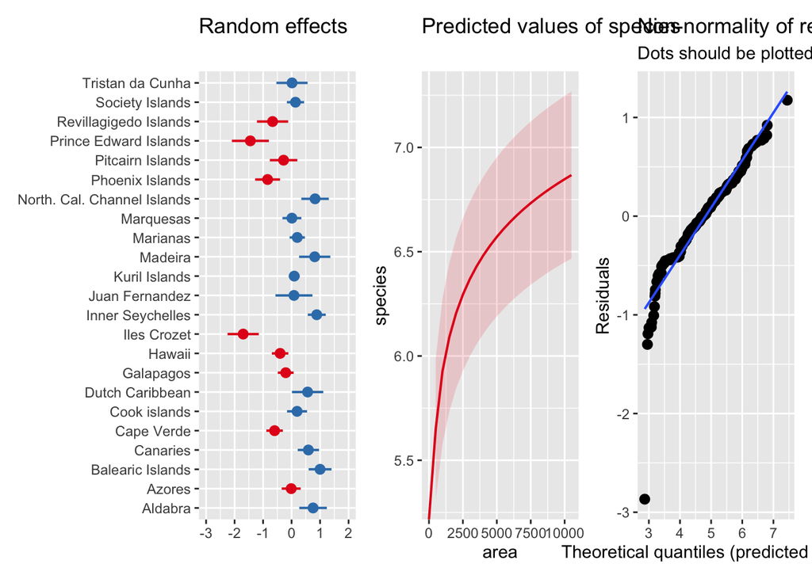

```r
mod_area <- lmer(log(species+1) ~ log10(area) + (1|archipelago), data = biogeo)
(plot_model(mod_area, type = "re")) +
  (plot_model(mod_area, type = "eff", terms = c('area'))) +
  (plot_model(mod_area, type = "diag")[[1]])
```

```r
anova(mod_area, type = '2')
```

```
## Type II Analysis of Variance Table with Satterthwaite's method
##             Sum Sq Mean Sq NumDF  DenDF F value    Pr(>F)
## log10(area)  85.14   85.14     1 157.07  312.84 < 2.2e-16 ***
## ---
## Signif. codes:  0 '***' 0.001 '**' 0.01 '*' 0.05 '.' 0.1 ' ' 1
```

```r
VarCorr(mod_area)
```

```
##  Groups      Name        Std.Dev.
##  archipelago (Intercept) 0.74929
##  Residual                0.52168
```

### Distance to continent

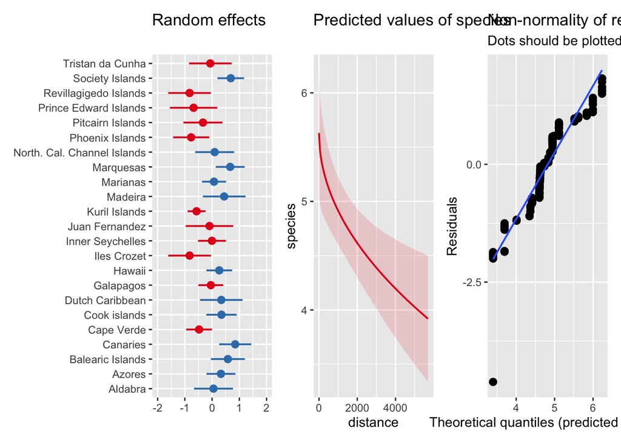

```r
mod_dist <- lmer(log(species+1) ~ sqrt(distance) + (1|archipelago), data = biogeo)
(plot_model(mod_dist, type = "re")) +
  (plot_model(mod_dist, type = "eff", terms = c('distance'))) +
  (plot_model(mod_dist, type = "diag")[[1]])
```

```r
anova(mod_dist, type = '2')
```

```
## Type II Analysis of Variance Table with Satterthwaite's method
##                Sum Sq Mean Sq NumDF  DenDF F value   Pr(>F)
## sqrt(distance) 9.5449  9.5449     1 17.216  11.597 0.003319 **
## ---
## Signif. codes:  0 '***' 0.001 '**' 0.01 '*' 0.05 '.' 0.1 ' ' 1
```

```r
VarCorr(mod_dist)
```

```
##  Groups      Name        Std.Dev.
##  archipelago (Intercept) 0.61725
##  Residual                0.90721
```

### Age

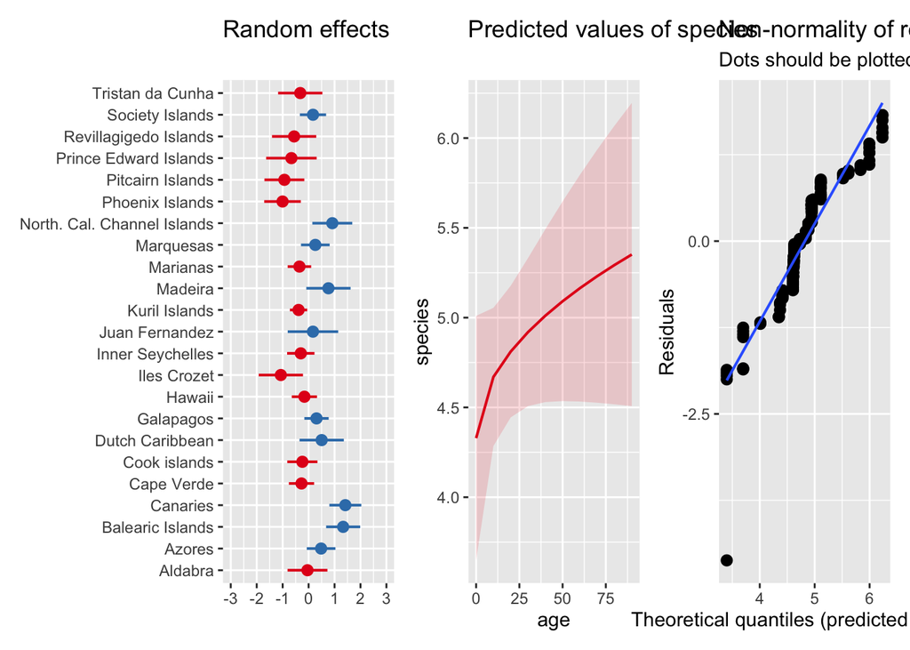

```r
mod_age <- lmer(log(species+1) ~ sqrt(age) + (1|archipelago), data = biogeo)
(plot_model(mod_age, type = "re")) +
  (plot_model(mod_age, type = "eff", terms = c('age'))) +
  (plot_model(mod_dist, type = "diag")[[1]])
```

```r
anova(mod_age, type = '2')
```

```
## Type II Analysis of Variance Table with Satterthwaite's method
##           Sum Sq Mean Sq NumDF  DenDF F value Pr(>F)
## sqrt(age) 1.8663  1.8663     1 18.992  2.2731 0.1481
```

```r
VarCorr(mod_age)
```

```
##  Groups      Name        Std.Dev.
##  archipelago (Intercept) 0.78565
##  Residual                0.90612
```

### Elevation

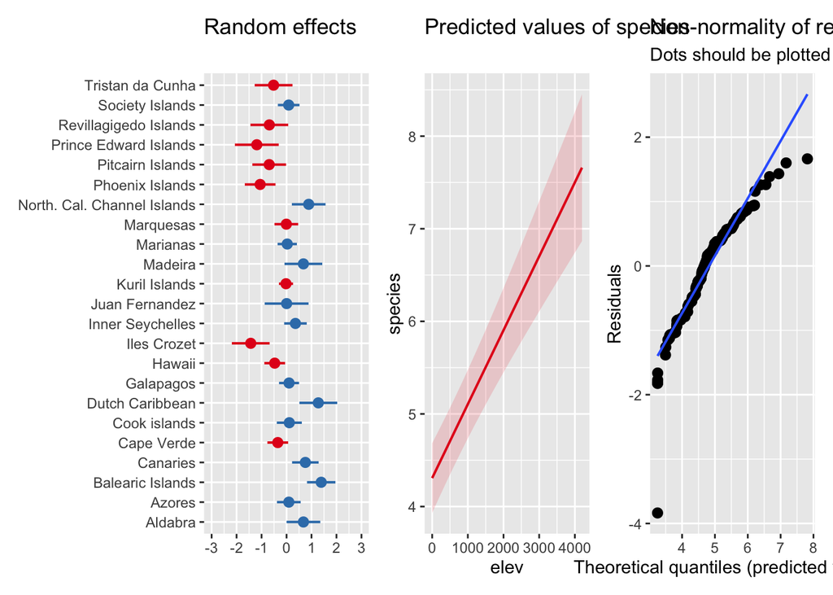

```r
mod_elev <- lmer(log(species+1) ~ elev + (1|archipelago), data = biogeo)
(plot_model(mod_elev, type = "re")) +
  (plot_model(mod_elev, type = "eff", terms = c('elev'))) +
  (plot_model(mod_elev, type = "diag")[[1]])
```

```r
anova(mod_elev, type = '2')
```

```
## Type II Analysis of Variance Table with Satterthwaite's method
##      Sum Sq Mean Sq NumDF  DenDF F value    Pr(>F)
## elev 37.998  37.998     1 161.43  65.493 1.329e-13 ***
## ---
## Signif. codes:  0 '***' 0.001 '**' 0.01 '*' 0.05 '.' 0.1 ' ' 1
```

```r
VarCorr(mod_elev)
```

```
##  Groups      Name        Std.Dev.
##  archipelago (Intercept) 0.80662
##  Residual                0.76170
```

### Temperature

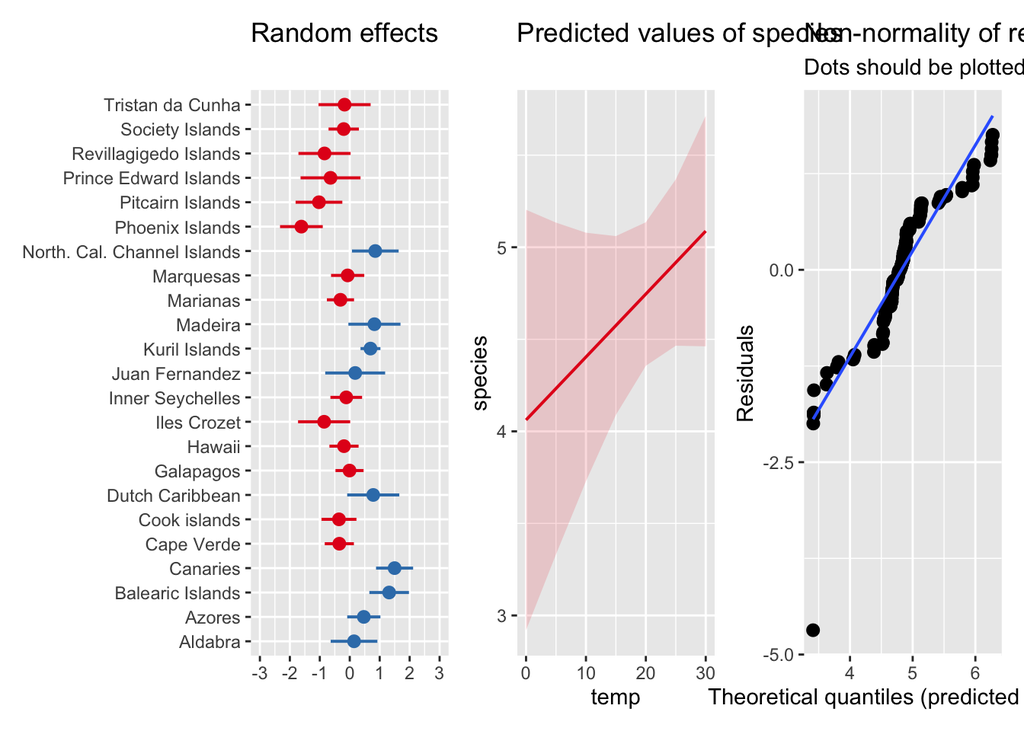

```r
mod_temp <- lmer(log(species+1) ~ temp + (1|archipelago), data = biogeo)

(plot_model(mod_temp, type = "re")) +
  (plot_model(mod_temp, type = "eff", terms = c('temp'))) +
  (plot_model(mod_temp, type = "diag")[[1]])
```

```r
anova(mod_temp, type = '2')
```

```
## Type II Analysis of Variance Table with Satterthwaite's method
##      Sum Sq Mean Sq NumDF  DenDF F value Pr(>F)
## temp 1.3551  1.3551     1 21.466  1.6759 0.2092
```

```r
VarCorr(mod_temp)
```

```
##  Groups      Name        Std.Dev.
##  archipelago (Intercept) 0.85691
##  Residual                0.89921
```

### Interpretation

Most promising explanatory variables: area, elevation, distance

## Question 4

### Making the model

```r
model_hyp <- lmer(log(species+1) ~ log10(area)*elev + elev + sqrt(distance) + (1|archipelago), data = biogeo)
```

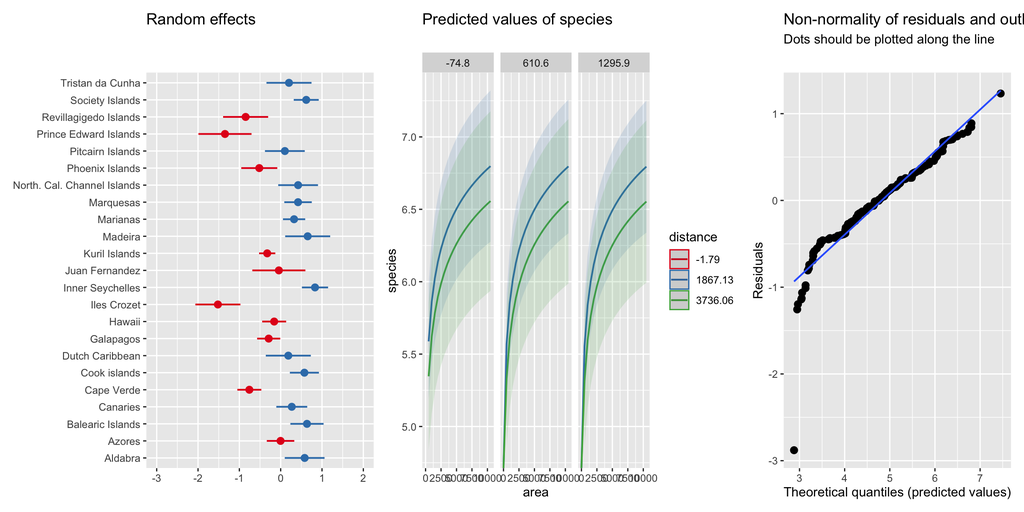

```r
(plot_model(model_hyp, type = "re")) +
  (plot_model(model_hyp, type = "eff", terms = c('area','distance', 'elev'))) +
  (plot_model(model_hyp, type = "diag")[[1]])
```

```r
summary(model_hyp)
```

```
## Linear mixed model fit by REML. t-tests use Satterthwaite's method [
## lmerModLmerTest]
## Formula: log(species + 1) ~ log10(area) * elev + elev + sqrt(distance) +
##     (1 | archipelago)
##    Data: biogeo
##
## REML criterion at convergence: 369.1
##
## Scaled residuals:
##     Min      1Q  Median      3Q     Max
## -5.4809 -0.4523  0.0940  0.5183  2.3464
##
## Random effects:
##  Groups      Name        Variance Std.Dev.
##  archipelago (Intercept) 0.4848   0.6963
##  Residual                0.2759   0.5253
## Number of obs: 174, groups:  archipelago, 23
##
## Fixed effects:
##                    Estimate Std. Error         df t value Pr(>|t|)
## (Intercept)       3.695e+00  3.232e-01  2.702e+01  11.432 7.42e-12 ***
## log10(area)       9.164e-01  7.205e-02  1.524e+02  12.718  < 2e-16 ***
## elev             -6.522e-05  2.704e-04  1.583e+02  -0.241   0.8097
## sqrt(distance)   -1.346e-02  6.791e-03  1.888e+01  -1.983   0.0621 .
## log10(area):elev  1.559e-05  8.244e-05  1.564e+02   0.189   0.8502
## ---
## Signif. codes:  0 '***' 0.001 '**' 0.01 '*' 0.05 '.' 0.1 ' ' 1
##
## Correlation of Fixed Effects:
##             (Intr) lg10() elev   sqrt()
## log10(area) -0.364
## elev        -0.126 -0.070
## sqrt(dstnc) -0.814  0.092  0.003
## log10(r):lv  0.178 -0.169 -0.939 -0.016
## fit warnings:
## Some predictor variables are on very different scales: consider rescaling
```

```r
VarCorr(model_hyp)
```

```
##  Groups      Name        Std.Dev.
##  archipelago (Intercept) 0.69628
##  Residual                0.52527
```

### Model with no interaction

```r
model_hyp_no_interaction <- lmer(log(species+1) ~ log10(area) + elev + sqrt(distance) + (1|archipelago), data = biogeo)

summary(model_hyp_no_interaction)
```

```
## Linear mixed model fit by REML. t-tests use Satterthwaite's method [
## lmerModLmerTest]
## Formula: log(species + 1) ~ log10(area) + elev + sqrt(distance) + (1 |
##     archipelago)
##    Data: biogeo
##
## REML criterion at convergence: 352.2
##
## Scaled residuals:
##     Min      1Q  Median      3Q     Max
## -5.4982 -0.4575  0.0965  0.5126  2.3439
##
## Random effects:
##  Groups      Name        Variance Std.Dev.
##  archipelago (Intercept) 0.4874   0.6981
##  Residual                0.2740   0.5234
## Number of obs: 174, groups:  archipelago, 23
##
## Fixed effects:
##                  Estimate Std. Error         df t value Pr(>|t|)
## (Intercept)     3.684e+00  3.185e-01  2.558e+01  11.567 1.17e-11 ***
## log10(area)     9.187e-01  7.078e-02  1.537e+02  12.981  < 2e-16 ***
## elev           -1.706e-05  9.261e-05  1.552e+02  -0.184   0.8541
## sqrt(distance) -1.345e-02  6.804e-03  1.902e+01  -1.977   0.0628 .
## ---
## Signif. codes:  0 '***' 0.001 '**' 0.01 '*' 0.05 '.' 0.1 ' ' 1
##
## Correlation of Fixed Effects:
##             (Intr) lg10() elev
## log10(area) -0.343
## elev         0.121 -0.675
## sqrt(dstnc) -0.824  0.090 -0.036
```

```r
anova(model_hyp_no_interaction, type = "2")
```

```
## Type II Analysis of Variance Table with Satterthwaite's method
##                Sum Sq Mean Sq NumDF   DenDF  F value  Pr(>F)
## log10(area)    46.164  46.164     1 153.736 168.4991 < 2e-16 ***
## elev            0.009   0.009     1 155.237   0.0340 0.85405
## sqrt(distance)  1.071   1.071     1  19.019   3.9074 0.06276 .
## ---
## Signif. codes:  0 '***' 0.001 '**' 0.01 '*' 0.05 '.' 0.1 ' ' 1
```

```r
VarCorr(model_hyp_no_interaction)
```

```
##  Groups      Name        Std.Dev.
##  archipelago (Intercept) 0.69812
##  Residual                0.52342
```

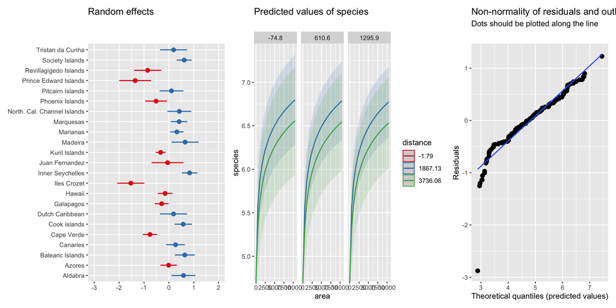

```r
(plot_model(model_hyp_no_interaction, type = "re")) +
  (plot_model(model_hyp_no_interaction, type = "eff", terms = c('area','distance', 'elev'))) +
  (plot_model(model_hyp_no_interaction, type = "diag")[[1]])
```

### Interpretation

- There is no interactions between the area of an island and it’s elevation.
- From the anova, the area has a significant F-value, indicating that it’s the most likely explanatory variable.
- Removing the interaction improve the Residual std. dev slightly.
- The denDF are not equal, they are higher for the area and the elevation. But that’s because the data are collected at the island scale. The distance denDF is lower because it’s measured at the archipelago scale.

**Conclusion**: the area of an island is highly associated with the species richness. The larger the island, the higher the species richness.

### AICc

```r
AIC(model_hyp_no_interaction)
```

```
## [1] 364.1569
```

```r
model.sel(model_hyp_no_interaction,model_hyp)
```

```
## Model selection table
##                          (Int)        elv l10(are) sqr(dst) elv:l10(are) df
## model_hyp_no_interaction 3.684 -1.706e-05   0.9187 -0.01345               6
## model_hyp                3.695 -6.522e-05   0.9164 -0.01346    1.559e-05  7
##                            logLik  AICc delta weight
## model_hyp_no_interaction -176.078 364.7  0.00      1
## model_hyp                -184.547 383.8 19.11      0
## Models ranked by AICc(x)
## Random terms (all models):
##   1 | archipelago
```